# CA CODE and GHE CSMF Comparison

Scatter plots and trends 2000-2021

# 5-9y

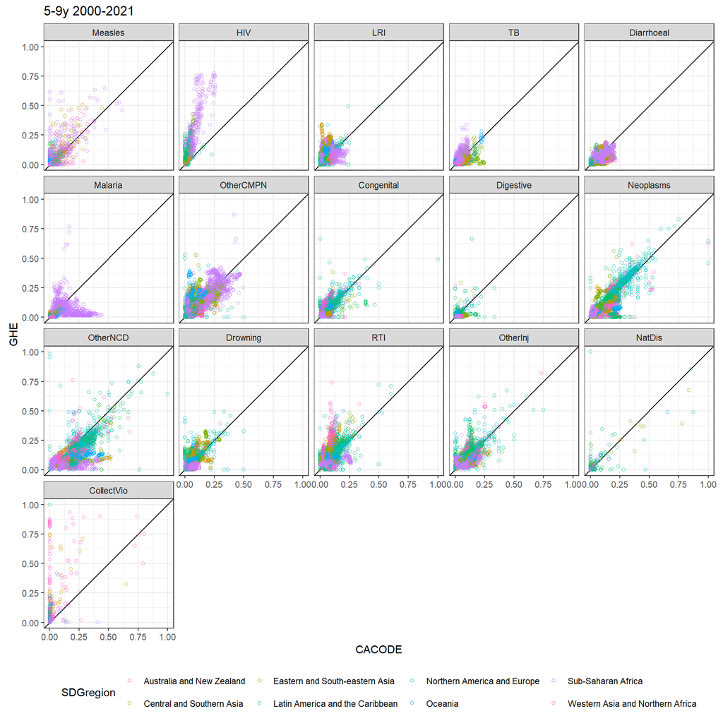

## CollectVio

Countries with large differences in CollectVio (CSMFs for GHE > 0.50 and CACODE < 0.10), all causes

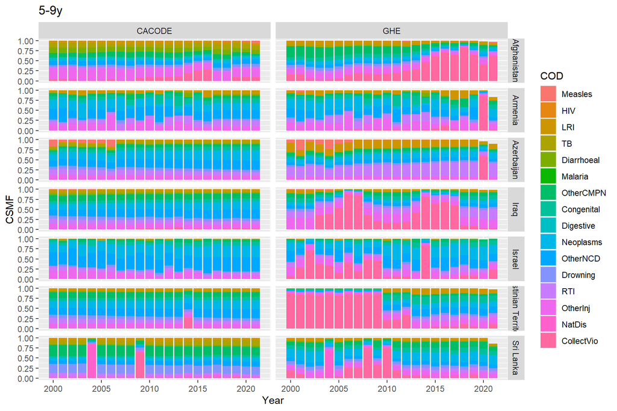

## HIV

Countries largest average difference in HIV

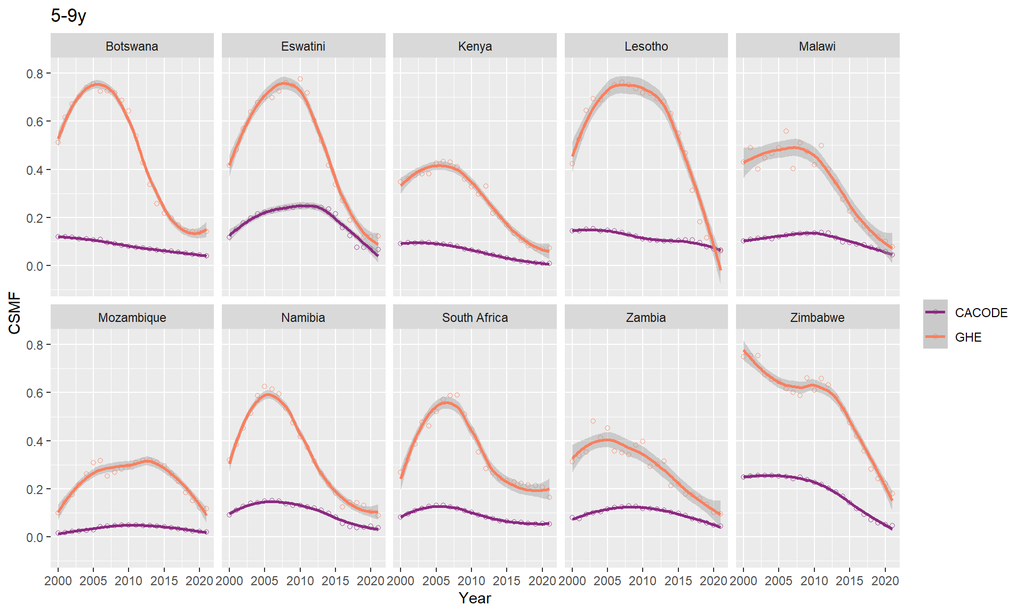

Countries with largest average difference in HIV, all causes

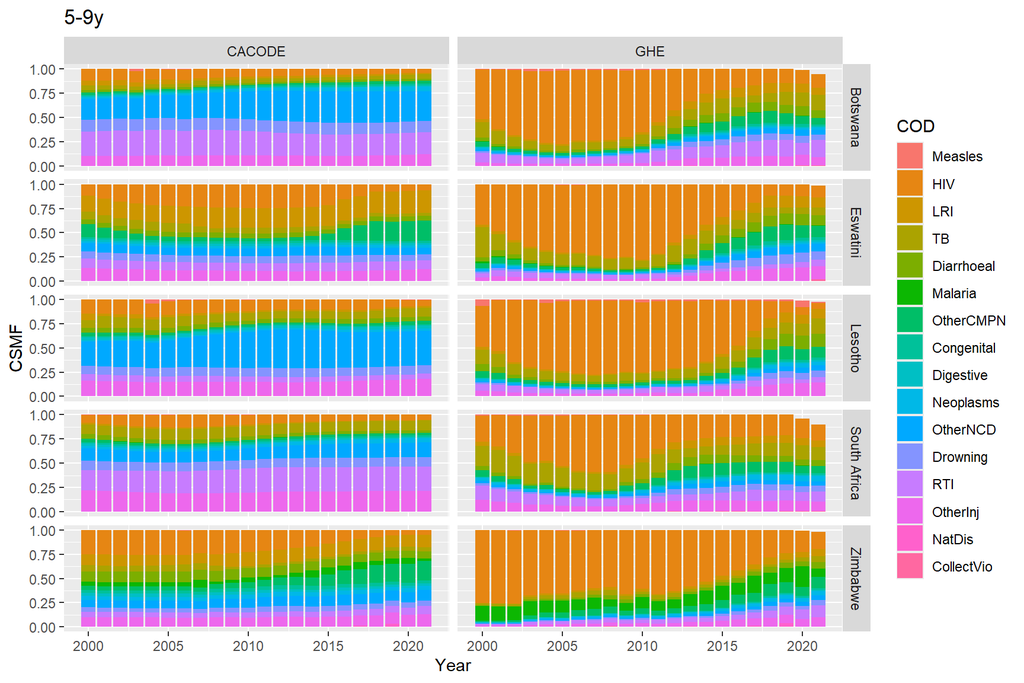

## Malaria

Countries largest average difference in malaria

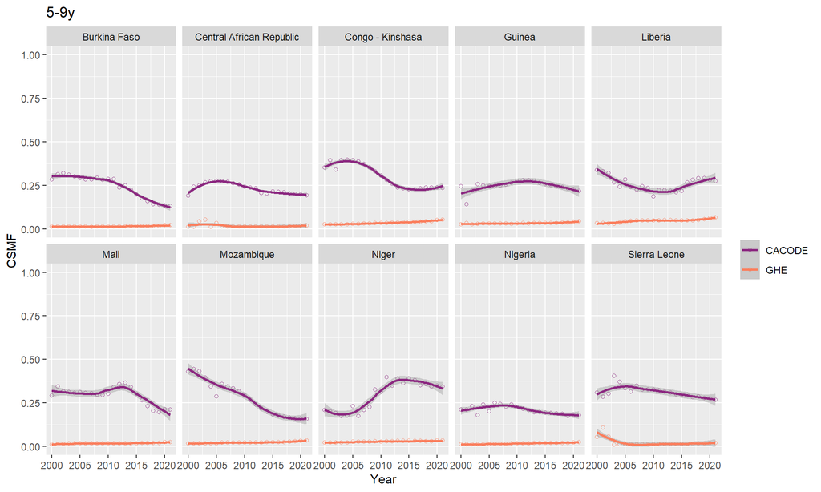

Countries with largest average difference in malaria, all causes

- Sometimes GHE has larger OtherCMPN fraction, sometimes measles and HIV

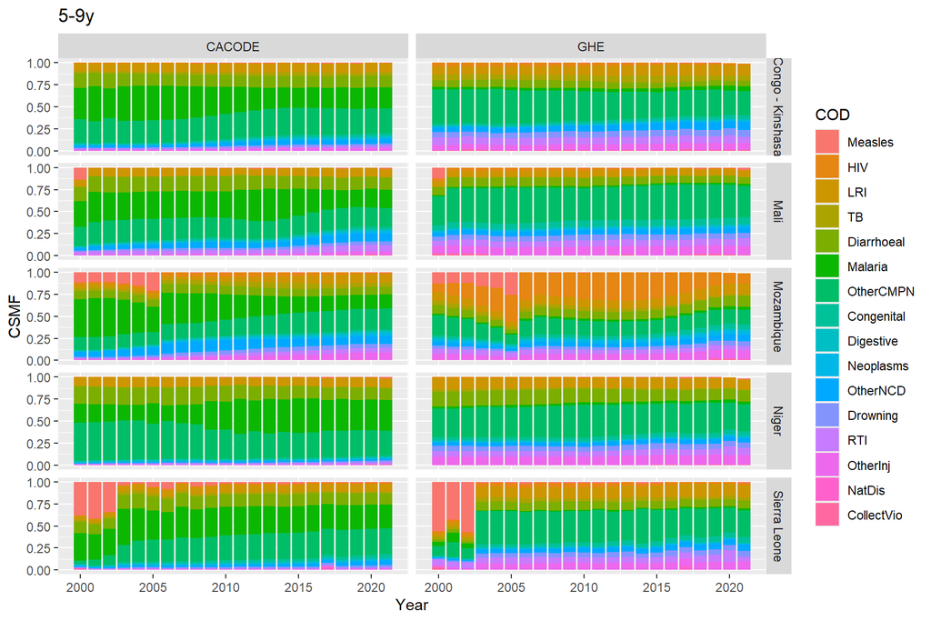

# 10-14

- GHE has higher HIV in sub-Saharan Africa
- CACODE has higher malaria in sub-Saharan Africa
- Same as 5-9y

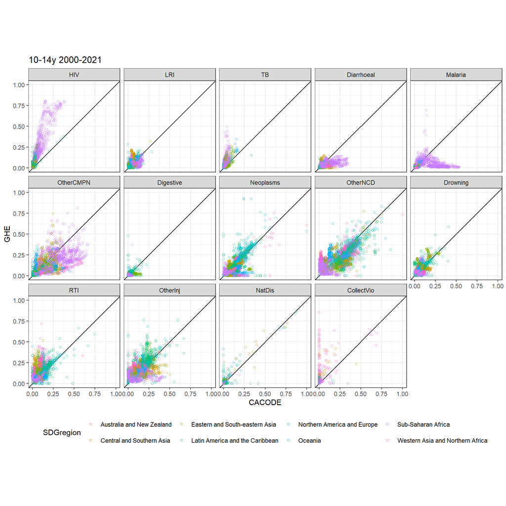

## Malaria

Countries with largest average difference in malaria, all causes

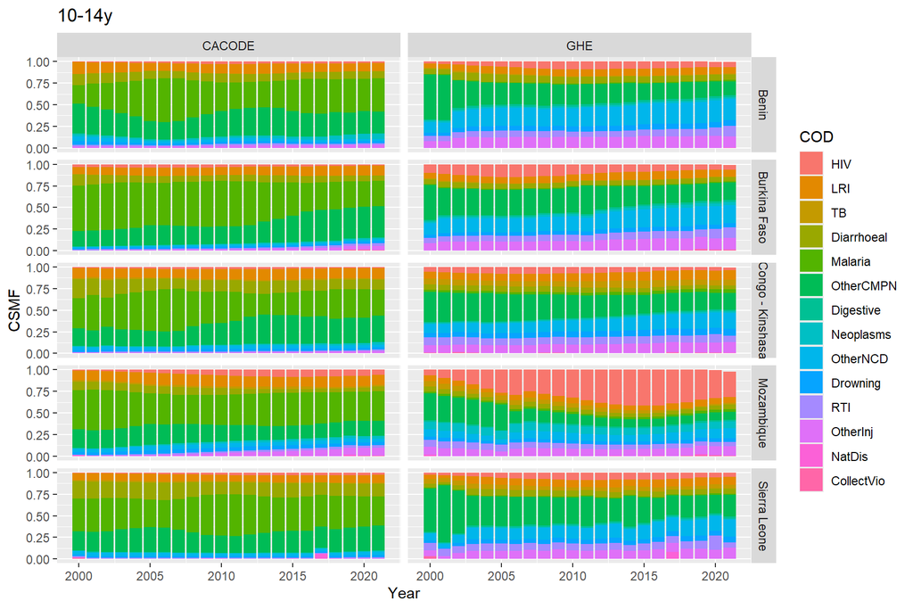

# 15-19 F

- GHE has higher maternal in sub-Saharan Africa
- CACODE has higher OtherCMPN in sub-Saharan Africa
- GHE has higher CollectVio in western and northern Africa

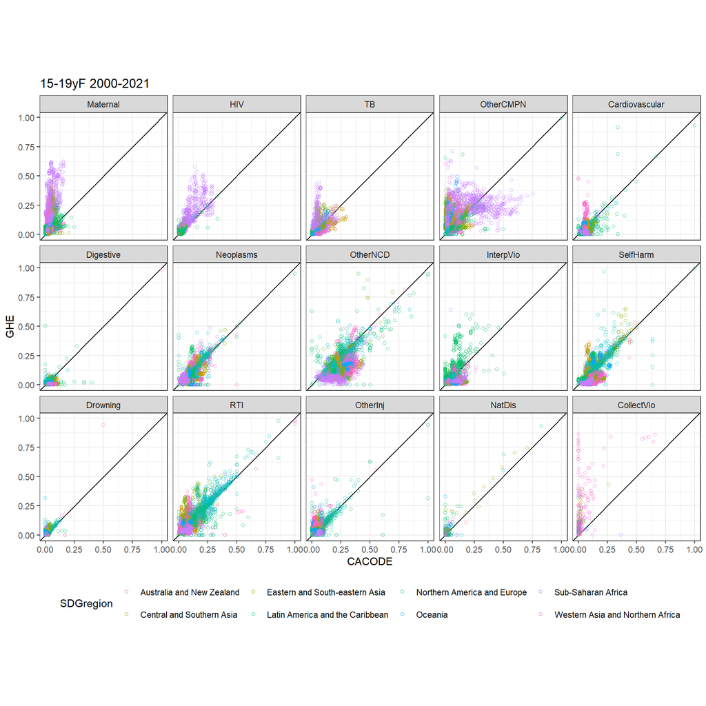

## Maternal

Countries largest average difference in Maternal

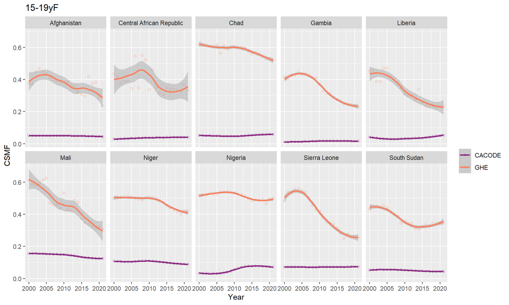

Countries with largest average difference in Maternal, all causes.

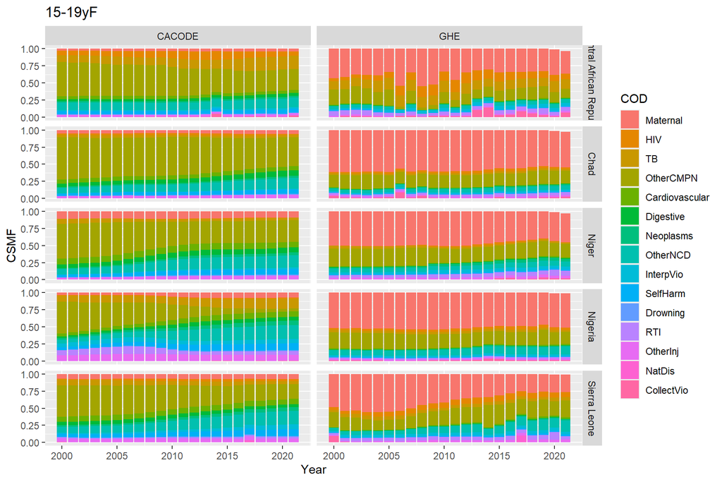

# 15-19 M

- GHE has higher RTI and CollectVio
- CACODE has higher InterpVio

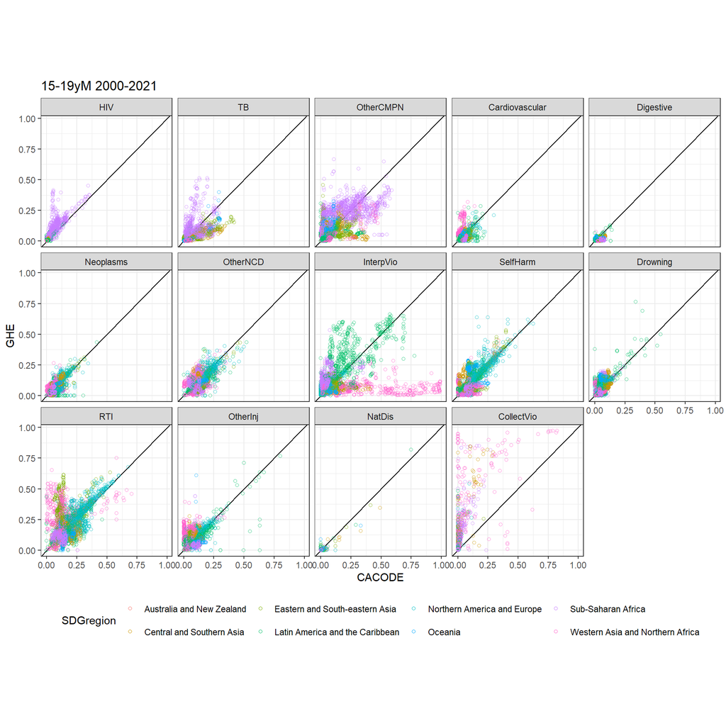

## CollectVio, InterpVio, RTI

Countries with largest average difference in CollectVio, InterpVio, and RTI.

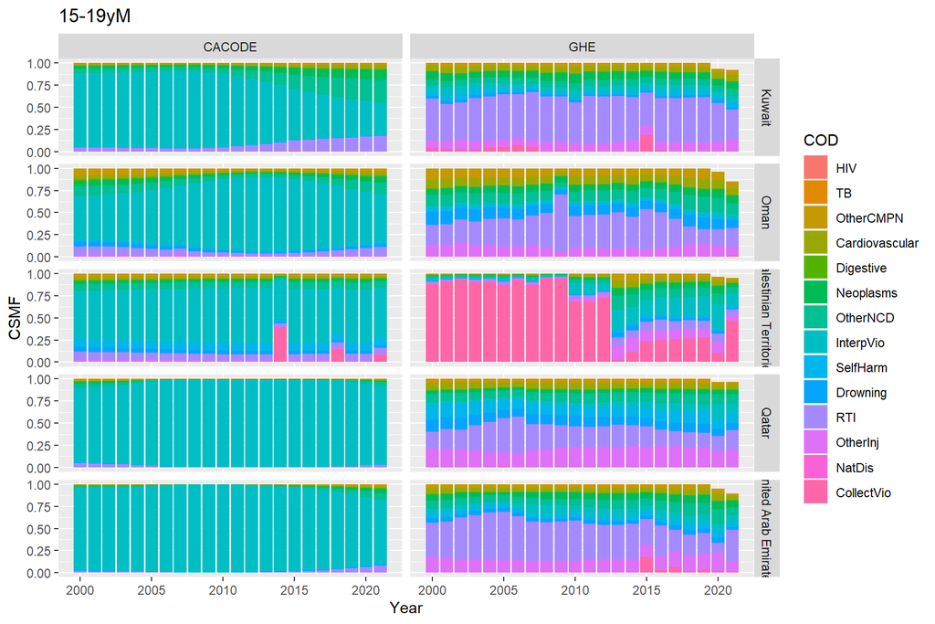